# Analyse multivariées Sputum

Nicolas Migueres

16/07/2020

#Analyse de régression logistique pour un critère T2 eosinophilie > à 3% SPUTUM pré SIC

##difficulté du choix des variables à utiliser dans le modèle car les associations peuvent différer selon le critère diagnostic utilisé. Cepandant, impossibilité de comparer deux modèles si variables différentes.

[output not shown]

[output not shown]

[output not shown]

[output not shown]

###Analyse multivariée selon les variables identifié à partir du critère T235

```
##
## Call:
## glm(formula = eosino_pre_sic_dich ~ bmi + age + sex + hmw.lmw +
##     smoker + asthma_pre + atopy + sinusitis + dyspnea_w + dysphonia_w +
##     nsbh.res + severity_ats + saba_sic + time_last_exp_m, family = binomial,
##     data = ms)
##
## Deviance Residuals:
##     Min       1Q   Median       3Q      Max
## -1.4391  -0.9794  -0.6406   1.1450   2.0827
##
## Coefficients:
##                             Estimate Std. Error z value Pr(>|z|)
## (Intercept)                -1.638108   1.027920  -1.594 0.111022
## bmi                        -0.027019   0.027395  -0.986 0.323989
## age                         0.010935   0.012399   0.882 0.377806
## sexmale                    -0.078516   0.272064  -0.289 0.772891
## hmw.lmwLMW                  0.091518   0.269010   0.340 0.733704
## smokerex                   -0.217560   0.362917  -0.599 0.548855
## smokernever                -0.086139   0.313889  -0.274 0.783757
## asthma_preyes              -1.104479   0.517005  -2.136 0.032655 *
## atopyyes                   -0.022852   0.260147  -0.088 0.930001
## sinusitisyes                0.129212   0.465298   0.278 0.781245
## dyspnea_wyes                0.359051   0.467058   0.769 0.442042
## dysphonia_wyes             -0.534482   0.382057  -1.399 0.161826
## nsbh.resmild                1.042807   0.356130   2.928 0.003410 **
## nsbh.resmoderate to severe  1.355482   0.397168   3.413 0.000643 ***
## severity_atsyes             0.158924   0.335009   0.474 0.635223
## saba_sicyes                 0.648547   0.278033   2.333 0.019668 *
## time_last_exp_m            -0.001057   0.007582  -0.139 0.889112
## ---
## Signif. codes:  0 '***' 0.001 '**' 0.01 '*' 0.05 '.' 0.1 ' ' 1
##
## (Dispersion parameter for binomial family taken to be 1)
##
##     Null deviance: 424.43  on 318  degrees of freedom
## Residual deviance: 388.69  on 302  degrees of freedom
## AIC: 422.69
##
## Number of Fisher Scoring iterations: 4
```

| **Characteristic** | **OR**<sup>1</sup> | **95% CI**<sup>1</sup> | **p-value** |
| --- | --- | --- | --- |
| bmi | 0.97 | 0.92, 1.03 | 0.3 |
| age | 1.01 | 0.99, 1.04 | 0.4 |
| sex |  |  |  |
| female | — | — |  |
| male | 0.92 | 0.54, 1.58 | 0.8 |
| hmw.lmw |  |  |  |
| HMW | — | — |  |
| LMW | 1.10 | 0.65, 1.86 | 0.7 |
| smoker |  |  |  |
| current | — | — |  |
| ex | 0.80 | 0.39, 1.64 | 0.5 |
| never | 0.92 | 0.50, 1.71 | 0.8 |
| asthma_pre |  |  |  |
| no | — | — |  |
| yes | 0.33 | 0.11, 0.87 | 0.033 |
| atopy |  |  |  |
| no | — | — |  |
| yes | 0.98 | 0.59, 1.63 | >0.9 |
| sinusitis |  |  |  |
| no | — | — |  |
| yes | 1.14 | 0.45, 2.81 | 0.8 |
| dyspnea_w |  |  |  |
| no | — | — |  |
| yes | 1.43 | 0.59, 3.75 | 0.4 |
| dysphonia_w |  |  |  |
| no | — | — |  |
| yes | 0.59 | 0.27, 1.22 | 0.2 |
| nsbh.res |  |  |  |
| negative | — | — |  |
| mild | 2.84 | 1.44, 5.87 | 0.003 |
| moderate to severe | 3.88 | 1.81, 8.66 | <0.001 |
| severity_ats |  |  |  |
| no | — | — |  |
| yes | 1.17 | 0.61, 2.26 | 0.6 |
| saba_sic |  |  |  |
| no | — | — |  |
| yes | 1.91 | 1.12, 3.33 | 0.020 |
| time_last_exp_m | 1.00 | 0.98, 1.01 | 0.9 |

<sup>*1*</sup> OR = Odds Ratio, CI = Confidence Interval

```
##                     GVIF Df GVIF^(1/(2*Df))
## bmi             1.154821  1        1.074626
## age             1.214948  1        1.102247
## sex             1.137387  1        1.066484
## hmw.lmw         1.165314  1        1.079497
## smoker          1.178141  2        1.041836
## asthma_pre      1.131532  1        1.063735
## atopy           1.140045  1        1.067729
## sinusitis       1.147704  1        1.071310
## dyspnea_w       1.081611  1        1.040005
## dysphonia_w     1.111884  1        1.054459
## nsbh.res        1.160441  2        1.037901
## severity_ats    1.224849  1        1.106729
## saba_sic        1.097616  1        1.047672
## time_last_exp_m 1.071478  1        1.035122
```

```
## Start:  AIC=422.69
## eosino_pre_sic_dich ~ bmi + age + sex + hmw.lmw + smoker + asthma_pre +
##     atopy + sinusitis + dyspnea_w + dysphonia_w + nsbh.res +
##     severity_ats + saba_sic + time_last_exp_m
##
##                   Df Deviance    AIC
## - smoker           2   389.06 419.06
## - atopy            1   388.70 420.70
## - time_last_exp_m  1   388.71 420.71
## - sinusitis        1   388.77 420.77
## - sex              1   388.77 420.77
## - hmw.lmw          1   388.81 420.81
## - severity_ats     1   388.92 420.92
## - dyspnea_w        1   389.30 421.30
## - age              1   389.47 421.47
## - bmi              1   389.68 421.68
## <none>                 388.69 422.69
## - dysphonia_w      1   390.73 422.73
## - asthma_pre       1   393.83 425.83
## - saba_sic         1   394.28 426.28
## - nsbh.res         2   402.19 432.19
##
## Step:  AIC=419.06
## eosino_pre_sic_dich ~ bmi + age + sex + hmw.lmw + asthma_pre +
##     atopy + sinusitis + dyspnea_w + dysphonia_w + nsbh.res +
##     severity_ats + saba_sic + time_last_exp_m
##
##                   Df Deviance    AIC
## - atopy            1   389.07 417.07
## - time_last_exp_m  1   389.08 417.08
## - hmw.lmw          1   389.17 417.17
## - sinusitis        1   389.18 417.18
## - sex              1   389.21 417.21
## - severity_ats     1   389.29 417.29
## - dyspnea_w        1   389.65 417.65
## - age              1   389.77 417.77
## - bmi              1   390.21 418.21
## - dysphonia_w      1   391.03 419.03
## <none>                 389.06 419.06
## - asthma_pre       1   394.09 422.09
```

[output cut: 132 more lines]

```
##               Df Deviance    AIC
## - dysphonia_w  1   394.25 404.25
## <none>             392.49 404.49
## - asthma_pre   1   398.10 408.10
## - saba_sic     1   398.96 408.96
## - nsbh.res     2   408.40 416.40
##
## Step:  AIC=404.25
## eosino_pre_sic_dich ~ asthma_pre + nsbh.res + saba_sic
##
##              Df Deviance    AIC
## <none>            394.25 404.25
## - asthma_pre  1   400.48 408.48
## - saba_sic    1   401.57 409.57
## - nsbh.res    2   410.24 416.24
```

```
##
## Call:  glm(formula = eosino_pre_sic_dich ~ asthma_pre + nsbh.res + saba_sic,
##     family = binomial, data = ms)
##
## Coefficients:
##                (Intercept)               asthma_preyes
##                    -1.8122                     -1.1153
##               nsbh.resmild  nsbh.resmoderate to severe
##                     1.0640                      1.3946
##                saba_sicyes
##                     0.6997
##
## Degrees of Freedom: 318 Total (i.e. Null);  314 Residual
## Null Deviance:       424.4
## Residual Deviance: 394.3     AIC: 404.3
```

```
##
## Call:
## glm(formula = eosino_pre_sic_dich ~ asthma_pre + nsbh.res + saba_sic,
##     family = binomial, data = ms)
##
## Deviance Residuals:
##     Min       1Q   Median       3Q      Max
## -1.2993  -1.0059  -0.7373   1.1981   2.0039
##
## Coefficients:
##                            Estimate Std. Error z value Pr(>|z|)
## (Intercept)                 -1.8122     0.3558  -5.093 3.52e-07 ***
## asthma_preyes               -1.1153     0.4826  -2.311 0.020829 *
## nsbh.resmild                 1.0640     0.3438   3.095 0.001970 **
## nsbh.resmoderate to severe   1.3946     0.3763   3.705 0.000211 ***
## saba_sicyes                  0.6997     0.2633   2.657 0.007880 **
## ---
## Signif. codes:  0 '***' 0.001 '**' 0.01 '*' 0.05 '.' 0.1 ' ' 1
##
## (Dispersion parameter for binomial family taken to be 1)
##
##     Null deviance: 424.43  on 318  degrees of freedom
## Residual deviance: 394.25  on 314  degrees of freedom
## AIC: 404.25
##
## Number of Fisher Scoring iterations: 4
```

| **Characteristic** | **OR**<sup>1</sup> | **95% CI**<sup>1</sup> | **p-value** |
| --- | --- | --- | --- |
| asthma_pre |  |  |  |
| no | — | — |  |
| yes | 0.33 | 0.12, 0.80 | 0.021 |
| nsbh.res |  |  |  |
| negative | — | — |  |
| mild | 2.90 | 1.51, 5.86 | 0.002 |
| moderate to severe | 4.03 | 1.97, 8.65 | <0.001 |
| saba_sic |  |  |  |
| no | — | — |  |
| yes | 2.01 | 1.21, 3.41 | 0.008 |

<sup>*1*</sup> OR = Odds Ratio, CI = Confidence Interval

```
##                GVIF Df GVIF^(1/(2*Df))
## asthma_pre 1.009099  1        1.004539
## nsbh.res   1.011052  2        1.002752
## saba_sic   1.002961  1        1.001480
```

####réalisation même modèle avec données manquantes seulement pour les variables d’intérets

```
##
## Call:
## glm(formula = eosino_pre_sic_dich ~ asthma_pre + nsbh.res + saba_sic,
##     family = binomial, data = dat)
##
## Deviance Residuals:
##     Min       1Q   Median       3Q      Max
## -1.2798  -1.0185  -0.7621   1.2394   2.2076
##
## Coefficients:
##                            Estimate Std. Error z value Pr(>|z|)
## (Intercept)                 -1.7113     0.3169  -5.400 6.66e-08 ***
## asthma_preyes               -0.6340     0.3676  -1.725  0.08462 .
## nsbh.resmild                 0.9431     0.3151   2.993  0.00276 **
## nsbh.resmoderate to severe   1.3254     0.3371   3.932 8.42e-05 ***
## saba_sicyes                  0.6235     0.2392   2.607  0.00914 **
## ---
## Signif. codes:  0 '***' 0.001 '**' 0.01 '*' 0.05 '.' 0.1 ' ' 1
##
## (Dispersion parameter for binomial family taken to be 1)
##
##     Null deviance: 496.60  on 373  degrees of freedom
## Residual deviance: 467.34  on 369  degrees of freedom
##   (48 observations deleted due to missingness)
## AIC: 477.34
##
## Number of Fisher Scoring iterations: 4
```

| **Characteristic** | **OR**<sup>1</sup> | **95% CI**<sup>1</sup> | **p-value** |
| --- | --- | --- | --- |
| asthma_pre |  |  |  |
| no | — | — |  |
| yes | 0.53 | 0.25, 1.07 | 0.085 |
| nsbh.res |  |  |  |
| negative | — | — |  |
| mild | 2.57 | 1.41, 4.87 | 0.003 |
| moderate to severe | 3.76 | 1.97, 7.44 | <0.001 |
| saba_sic |  |  |  |
| no | — | — |  |
| yes | 1.87 | 1.17, 3.00 | 0.009 |

<sup>*1*</sup> OR = Odds Ratio, CI = Confidence Interval

## variable avec association en régression logistique univarié avec p<0,1 :

asthma_pre+asthma_delay+ cough_w+ dyspnea_w+ dysphonia_w+ saba_sic+laba_sic+exa_2+baseline_fev1+tiffeneau +airway_obstruction+nsbh.res+severity_ats+ ics_sic+time_last_exp_m_norm+exacerbation_w_n

Pas de signification pour la variable asthma_control_sic ou asthma_control_w

Forte corrélation en ICS_sic et Laba_sic (indice vif à 2.5)

```
##
## Call:
## glm(formula = eosino_pre_sic_dich ~ asthma_pre + asthma_delay +
##     cough_w + dyspnea_w + dysphonia_w + saba_sic + nsbh.res +
##     severity_ats + time_last_exp_m_norm + ics_sic + exacerbation_w_n,
##     family = binomial, data = ms2)
##
## Deviance Residuals:
##     Min       1Q   Median       3Q      Max
## -1.5897  -0.9584  -0.6615   1.1289   2.0649
##
## Coefficients:
##                              Estimate Std. Error z value Pr(>|z|)
## (Intercept)                -2.4187678  0.6464584  -3.742 0.000183 ***
## asthma_preyes              -0.8306837  0.4890036  -1.699 0.089371 .
## asthma_delay                0.0007185  0.0011396   0.630 0.528380
## cough_wyes                  0.2362486  0.3827400   0.617 0.537066
## dyspnea_wyes                0.3120112  0.4688143   0.666 0.505710
## dysphonia_wyes             -0.3521717  0.3804146  -0.926 0.354572
## saba_sicyes                 0.3807178  0.2916957   1.305 0.191829
## nsbh.resmild                0.9772435  0.3522583   2.774 0.005533 **
## nsbh.resmoderate to severe  1.2354139  0.3918883   3.152 0.001619 **
## severity_atsyes             0.0117262  0.3541859   0.033 0.973589
## time_last_exp_m_norm       -0.2147693  0.1056238  -2.033 0.042018 *
## ics_sicyes                  0.4483222  0.3030552   1.479 0.139049
## exacerbation_w_n            0.1190045  0.0975313   1.220 0.222401
## ---
## Signif. codes:  0 '***' 0.001 '**' 0.01 '*' 0.05 '.' 0.1 ' ' 1
##
## (Dispersion parameter for binomial family taken to be 1)
##
##     Null deviance: 428.18  on 319  degrees of freedom
## Residual deviance: 386.47  on 307  degrees of freedom
## AIC: 412.47
##
## Number of Fisher Scoring iterations: 4
```

| **Characteristic** | **OR**<sup>1</sup> | **95% CI**<sup>1</sup> | **p-value** |
| --- | --- | --- | --- |
| asthma_pre |  |  |  |
| no | — | — |  |
| yes | 0.44 | 0.16, 1.09 | 0.089 |
| asthma_delay | 1.00 | 1.00, 1.00 | 0.5 |
| cough_w |  |  |  |
| no | — | — |  |
| yes | 1.27 | 0.61, 2.74 | 0.5 |
| dyspnea_w |  |  |  |
| no | — | — |  |
| yes | 1.37 | 0.56, 3.59 | 0.5 |
| dysphonia_w |  |  |  |
| no | — | — |  |
| yes | 0.70 | 0.32, 1.46 | 0.4 |
| saba_sic |  |  |  |
| no | — | — |  |
| yes | 1.46 | 0.83, 2.61 | 0.2 |
| nsbh.res |  |  |  |
| negative | — | — |  |
| mild | 2.66 | 1.36, 5.45 | 0.006 |
| moderate to severe | 3.44 | 1.62, 7.59 | 0.002 |
| severity_ats |  |  |  |
| no | — | — |  |
| yes | 1.01 | 0.50, 2.03 | >0.9 |
| time_last_exp_m_norm | 0.81 | 0.65, 0.99 | 0.042 |
| ics_sic |  |  |  |
| no | — | — |  |
| yes | 1.57 | 0.87, 2.86 | 0.14 |
| exacerbation_w_n | 1.13 | 0.94, 1.38 | 0.2 |

<sup>*1*</sup> OR = Odds Ratio, CI = Confidence Interval

```
##                          GVIF Df GVIF^(1/(2*Df))
## asthma_pre           1.081811  1        1.040102
## asthma_delay         1.104319  1        1.050866
## cough_w              1.067777  1        1.033333
## dyspnea_w            1.063534  1        1.031278
## dysphonia_w          1.100293  1        1.048949
## saba_sic             1.171814  1        1.082503
## nsbh.res             1.083402  2        1.020228
## severity_ats         1.383440  1        1.176197
## time_last_exp_m_norm 1.087806  1        1.042979
## ics_sic              1.178976  1        1.085806
## exacerbation_w_n     1.225937  1        1.107220
```

```
## Start:  AIC=412.47
## eosino_pre_sic_dich ~ asthma_pre + asthma_delay + cough_w + dyspnea_w +
##     dysphonia_w + saba_sic + nsbh.res + severity_ats + time_last_exp_m_norm +
##     ics_sic + exacerbation_w_n
##
##                        Df Deviance    AIC
## - severity_ats          1   386.47 410.47
## - cough_w               1   386.86 410.86
## - asthma_delay          1   386.87 410.87
## - dyspnea_w             1   386.92 410.92
## - dysphonia_w           1   387.35 411.35
## - exacerbation_w_n      1   388.04 412.04
## - saba_sic              1   388.19 412.19
## <none>                      386.47 412.47
## - ics_sic               1   388.69 412.69
## - asthma_pre            1   389.61 413.61
## - time_last_exp_m_norm  1   390.63 414.63
## - nsbh.res              2   398.05 420.05
##
## Step:  AIC=410.47
## eosino_pre_sic_dich ~ asthma_pre + asthma_delay + cough_w + dyspnea_w +
##     dysphonia_w + saba_sic + nsbh.res + time_last_exp_m_norm +
##     ics_sic + exacerbation_w_n
##
##                        Df Deviance    AIC
## - cough_w               1   386.86 408.86
## - asthma_delay          1   386.87 408.87
## - dyspnea_w             1   386.92 408.92
## - dysphonia_w           1   387.38 409.38
## - saba_sic              1   388.21 410.21
## - exacerbation_w_n      1   388.38 410.38
## <none>                      386.47 410.47
## - ics_sic               1   388.81 410.81
## - asthma_pre            1   389.61 411.61
## - time_last_exp_m_norm  1   390.64 412.64
## - nsbh.res              2   398.48 418.48
##
## Step:  AIC=408.86
## eosino_pre_sic_dich ~ asthma_pre + asthma_delay + dyspnea_w +
##     dysphonia_w + saba_sic + nsbh.res + time_last_exp_m_norm +
```

[output cut: 40 more lines]

```
## - asthma_pre            1   392.33 408.33
## - nsbh.res              2   399.73 413.73
##
## Step:  AIC=404.77
## eosino_pre_sic_dich ~ asthma_pre + saba_sic + nsbh.res + time_last_exp_m_norm +
##     ics_sic + exacerbation_w_n
##
##                        Df Deviance    AIC
## <none>                      388.77 404.77
## - exacerbation_w_n      1   391.01 405.01
## - saba_sic              1   391.45 405.45
## - ics_sic               1   391.94 405.94
## - time_last_exp_m_norm  1   393.57 407.57
## - asthma_pre            1   393.65 407.65
## - nsbh.res              2   400.70 412.70
```

```
##
## Call:  glm(formula = eosino_pre_sic_dich ~ asthma_pre + saba_sic + nsbh.res +
##     time_last_exp_m_norm + ics_sic + exacerbation_w_n, family = binomial,
##     data = ms2)
##
## Coefficients:
##                (Intercept)               asthma_preyes
##                    -1.9595                     -0.9829
##                saba_sicyes                nsbh.resmild
##                     0.4618                      0.9574
## nsbh.resmoderate to severe        time_last_exp_m_norm
##                     1.2393                     -0.2236
##                 ics_sicyes            exacerbation_w_n
##                     0.5119                      0.1288
##
## Degrees of Freedom: 319 Total (i.e. Null);  312 Residual
## Null Deviance:       428.2
## Residual Deviance: 388.8     AIC: 404.8
```

```
##
## Call:
## glm(formula = eosino_pre_sic_dich ~ asthma_pre + saba_sic + exacerbation_w_n +
##     ics_sic + time_last_exp_m_norm + nsbh.res, family = binomial,
##     data = ms2)
##
## Deviance Residuals:
##     Min       1Q   Median       3Q      Max
## -1.5945  -0.9806  -0.6730   1.1303   1.9596
##
## Coefficients:
##                            Estimate Std. Error z value Pr(>|z|)
## (Intercept)                -1.95953    0.39463  -4.966 6.85e-07 ***
## asthma_preyes              -0.98289    0.47167  -2.084  0.03717 *
## saba_sicyes                 0.46181    0.28388   1.627  0.10378
## exacerbation_w_n            0.12884    0.08908   1.446  0.14806
## ics_sicyes                  0.51187    0.29030   1.763  0.07785 .
## time_last_exp_m_norm       -0.22363    0.10247  -2.182  0.02908 *
## nsbh.resmild                0.95739    0.34941   2.740  0.00614 **
## nsbh.resmoderate to severe  1.23934    0.38392   3.228  0.00125 **
## ---
## Signif. codes:  0 '***' 0.001 '**' 0.01 '*' 0.05 '.' 0.1 ' ' 1
##
## (Dispersion parameter for binomial family taken to be 1)
##
##     Null deviance: 428.18  on 319  degrees of freedom
## Residual deviance: 388.77  on 312  degrees of freedom
## AIC: 404.77
##
## Number of Fisher Scoring iterations: 4
```

```
##                          GVIF Df GVIF^(1/(2*Df))
## asthma_pre           1.021113  1        1.010502
## saba_sic             1.119102  1        1.057876
## exacerbation_w_n     1.037545  1        1.018600
## ics_sic              1.089516  1        1.043799
## time_last_exp_m_norm 1.031007  1        1.015385
## nsbh.res             1.029657  2        1.007333
```

| **Characteristic** | **OR**<sup>1</sup> | **95% CI**<sup>1</sup> | **p-value** |
| --- | --- | --- | --- |
| asthma_pre |  |  |  |
| no | — | — |  |
| yes | 0.37 | 0.14, 0.90 | 0.037 |
| saba_sic |  |  |  |
| no | — | — |  |
| yes | 1.59 | 0.91, 2.79 | 0.10 |
| exacerbation_w_n | 1.14 | 0.96, 1.37 | 0.15 |
| ics_sic |  |  |  |
| no | — | — |  |
| yes | 1.67 | 0.95, 2.97 | 0.078 |
| time_last_exp_m_norm | 0.80 | 0.65, 0.98 | 0.029 |
| nsbh.res |  |  |  |
| negative | — | — |  |
| mild | 2.60 | 1.34, 5.32 | 0.006 |
| moderate to severe | 3.45 | 1.66, 7.51 | 0.001 |

<sup>*1*</sup> OR = Odds Ratio, CI = Confidence Interval

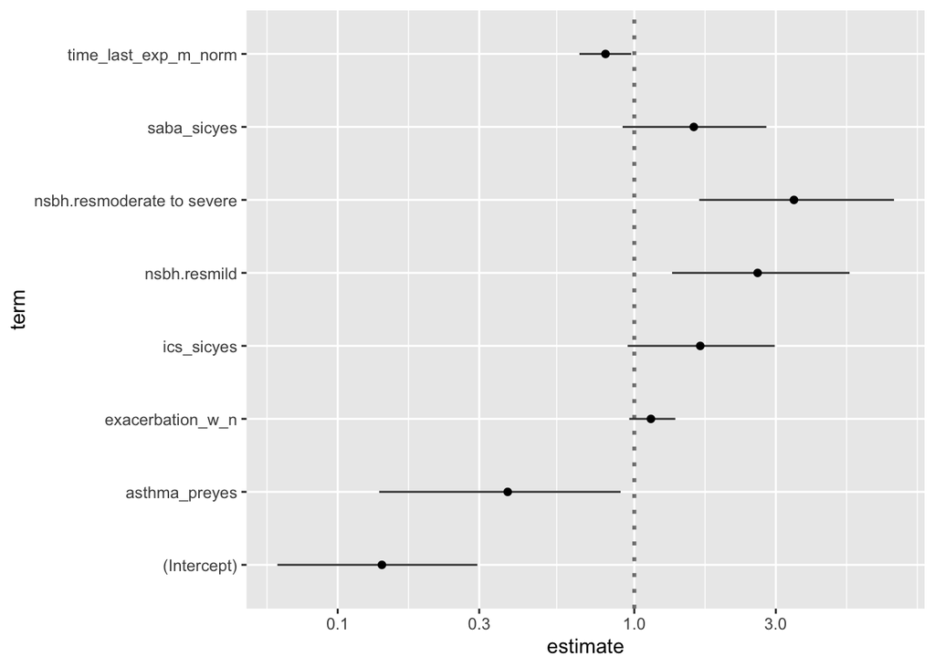

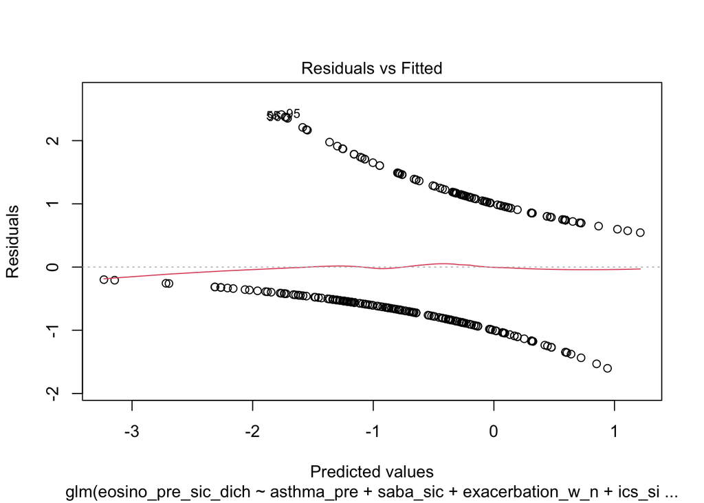

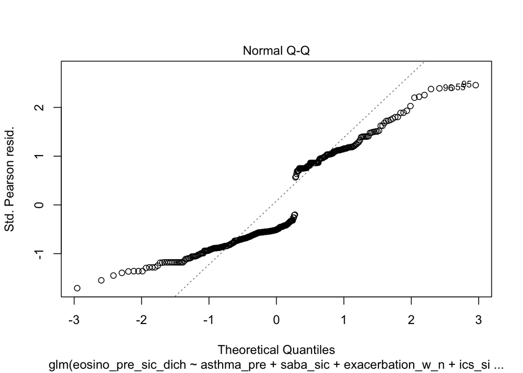

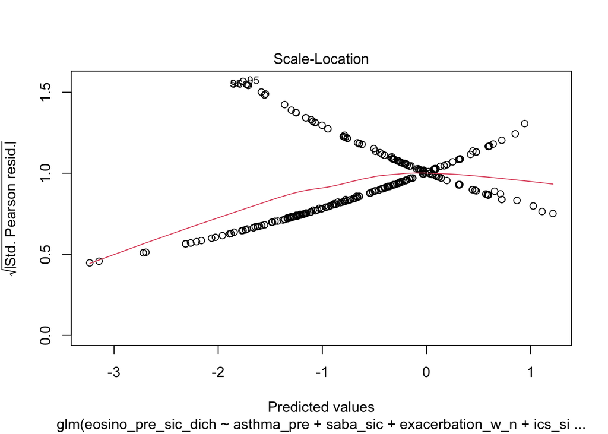

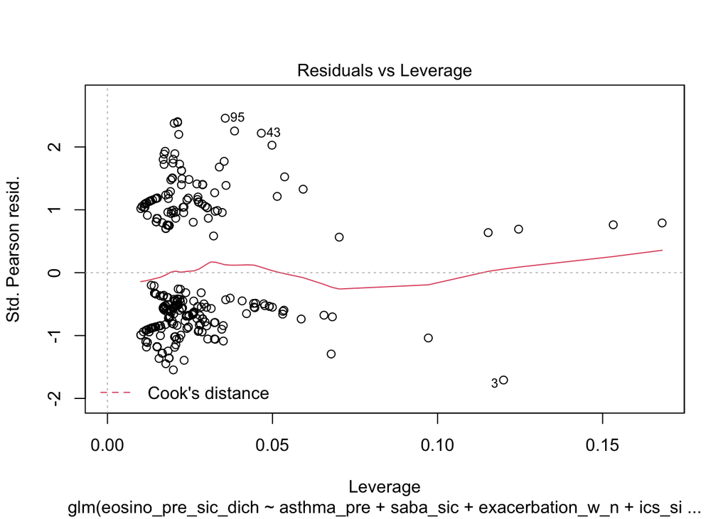

```
## Analysis of Deviance Table
##
## Model 1: eosino_pre_sic_dich ~ asthma_pre + saba_sic + exacerbation_w_n +
##     ics_sic + time_last_exp_m_norm + nsbh.res
## Model 2: eosino_pre_sic_dich ~ 1
##   Resid. Df Resid. Dev Df Deviance  Pr(>Chi)
## 1       312     388.77
## 2       319     428.18 -7  -39.407 1.634e-06 ***
## ---
## Signif. codes:  0 '***' 0.001 '**' 0.01 '*' 0.05 '.' 0.1 ' ' 1
```

##modèle avec donnée manquante cas complet que pour les variables finales: 363 patients contre 320

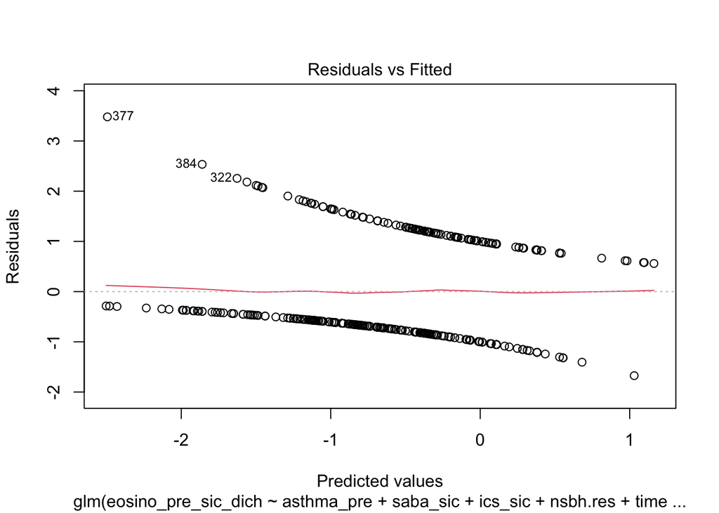

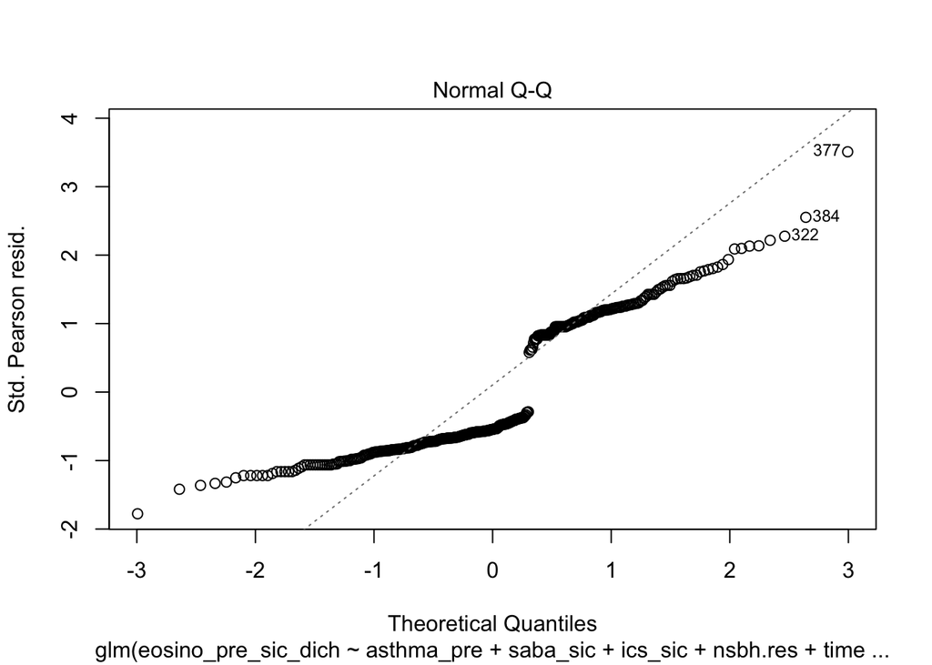

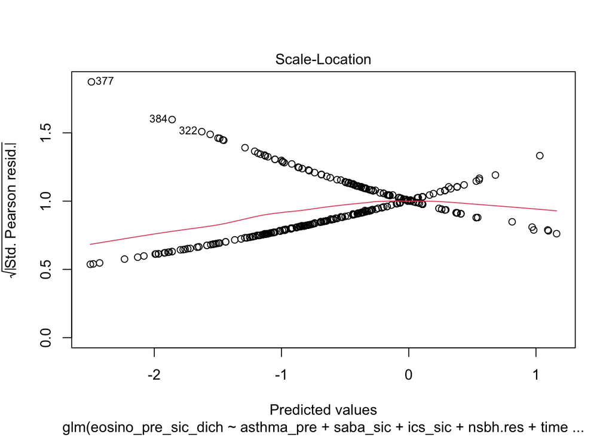

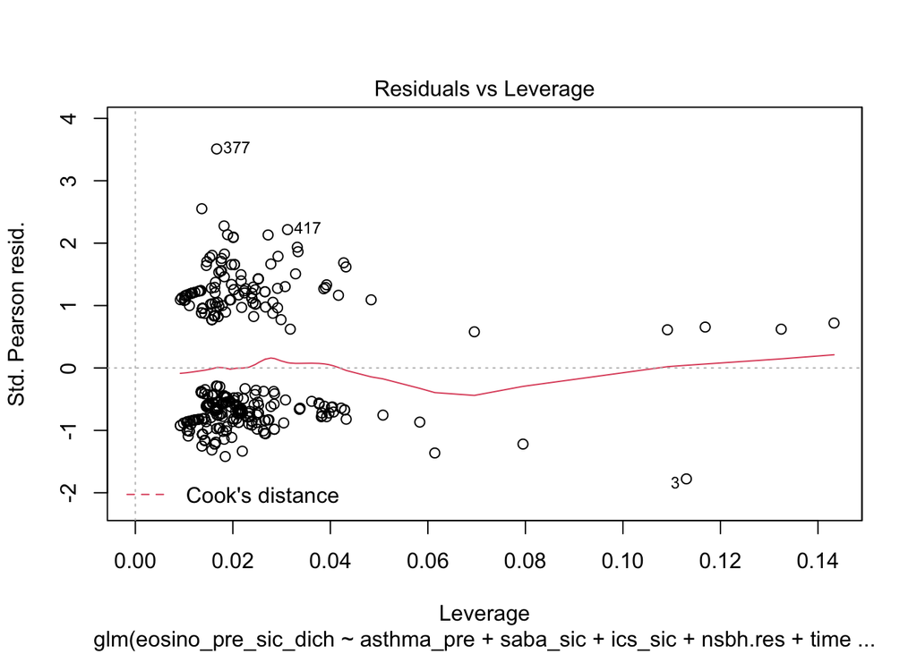

```
##
## Call:
## glm(formula = eosino_pre_sic_dich ~ asthma_pre + saba_sic + ics_sic +
##     nsbh.res + time_last_exp_m_norm + exacerbation_w_n, family = binomial,
##     data = dat)
##
## Deviance Residuals:
##     Min       1Q   Median       3Q      Max
## -1.6342  -0.9784  -0.7160   1.1709   2.2687
##
## Coefficients:
##                            Estimate Std. Error z value Pr(>|z|)
## (Intercept)                -1.71759    0.33905  -5.066 4.06e-07 ***
## asthma_preyes              -0.54691    0.37707  -1.450  0.14694
## saba_sicyes                 0.44658    0.26031   1.716  0.08624 .
## ics_sicyes                  0.30601    0.26352   1.161  0.24555
## nsbh.resmild                0.79476    0.32197   2.468  0.01357 *
## nsbh.resmoderate to severe  1.06653    0.34712   3.073  0.00212 **
## time_last_exp_m_norm       -0.18295    0.09523  -1.921  0.05472 .
## exacerbation_w_n            0.15055    0.08845   1.702  0.08875 .
## ---
## Signif. codes:  0 '***' 0.001 '**' 0.01 '*' 0.05 '.' 0.1 ' ' 1
##
## (Dispersion parameter for binomial family taken to be 1)
##
##     Null deviance: 482.17  on 362  degrees of freedom
## Residual deviance: 448.01  on 355  degrees of freedom
##   (59 observations deleted due to missingness)
## AIC: 464.01
##
## Number of Fisher Scoring iterations: 4
```

```
##                          GVIF Df GVIF^(1/(2*Df))
## asthma_pre           1.014502  1        1.007225
## saba_sic             1.139398  1        1.067426
## ics_sic              1.130812  1        1.063396
## nsbh.res             1.035180  2        1.008681
## time_last_exp_m_norm 1.026568  1        1.013197
## exacerbation_w_n     1.031969  1        1.015859
```

| **Characteristic** | **OR**<sup>1</sup> | **95% CI**<sup>1</sup> | **p-value** |
| --- | --- | --- | --- |
| asthma_pre |  |  |  |
| no | — | — |  |
| yes | 0.58 | 0.27, 1.18 | 0.15 |
| saba_sic |  |  |  |
| no | — | — |  |
| yes | 1.56 | 0.94, 2.62 | 0.086 |
| ics_sic |  |  |  |
| no | — | — |  |
| yes | 1.36 | 0.81, 2.29 | 0.2 |
| nsbh.res |  |  |  |
| negative | — | — |  |
| mild | 2.21 | 1.20, 4.25 | 0.014 |
| moderate to severe | 2.91 | 1.49, 5.85 | 0.002 |
| time_last_exp_m_norm | 0.83 | 0.69, 1.00 | 0.055 |
| exacerbation_w_n | 1.16 | 0.99, 1.40 | 0.089 |

<sup>*1*</sup> OR = Odds Ratio, CI = Confidence Interval

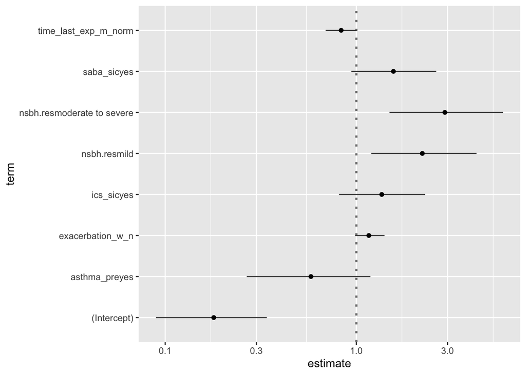

###Analyse données manquante par ACP

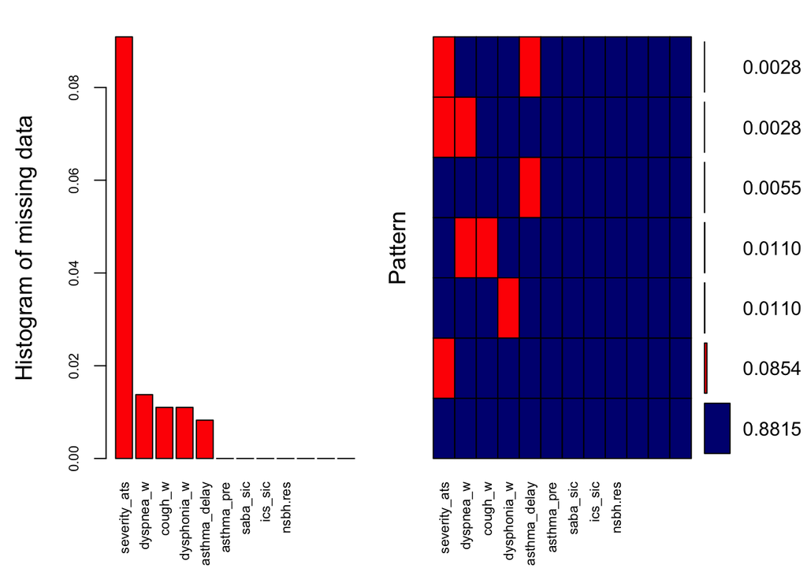

```
##
##  Variables sorted by number of missings:
##              Variable       Count
##          severity_ats 0.090909091
##             dyspnea_w 0.013774105
##               cough_w 0.011019284
##           dysphonia_w 0.011019284
##          asthma_delay 0.008264463
##            asthma_pre 0.000000000
##              saba_sic 0.000000000
##               ics_sic 0.000000000
##              nsbh.res 0.000000000
##   eosino_pre_sic_dich 0.000000000
##  time_last_exp_m_norm 0.000000000
##      exacerbation_w_n 0.000000000
```

```
## Class: mids
## Number of multiple imputations:  5
## Imputation methods:
##           asthma_pre         asthma_delay              cough_w
##                   ""                "pmm"                "pmm"
##            dyspnea_w          dysphonia_w             saba_sic
##                "pmm"                "pmm"                   ""
##              ics_sic             nsbh.res         severity_ats
##                   ""                   ""                "pmm"
##  eosino_pre_sic_dich time_last_exp_m_norm     exacerbation_w_n
##                   ""                   ""                   ""
## PredictorMatrix:
##              asthma_pre asthma_delay cough_w dyspnea_w dysphonia_w saba_sic
## asthma_pre            0            1       1         1           1        1
## asthma_delay          1            0       1         1           1        1
## cough_w               1            1       0         1           1        1
## dyspnea_w             1            1       1         0           1        1
## dysphonia_w           1            1       1         1           0        1
## saba_sic              1            1       1         1           1        0
##              ics_sic nsbh.res severity_ats eosino_pre_sic_dich
## asthma_pre         1        1            1                   1
## asthma_delay       1        1            1                   1
## cough_w            1        1            1                   1
## dyspnea_w          1        1            1                   1
## dysphonia_w        1        1            1                   1
## saba_sic           1        1            1                   1
##              time_last_exp_m_norm exacerbation_w_n
## asthma_pre                      1                1
## asthma_delay                    1                1
## cough_w                         1                1
## dyspnea_w                       1                1
## dysphonia_w                     1                1
## saba_sic                        1                1
```

```
##
## Call:
## PCA(X = msacpt, scale.unit = TRUE, ind.sup = c(11, 24, 30, 70,
##      79, 82, 88, 89, 97, 98, 100, 109, 145, 153, 159, 164, 178,
##      213, 323, 324, 326, 328, 330, 333, 334, 338, 339, 340, 341,
##      345, 347, 349, 352, 353, 354, 355, 356, 357, 359, 360, 361,
##      362, 363), graph = FALSE)
##
##
## Eigenvalues
##                        Dim.1   Dim.2   Dim.3   Dim.4   Dim.5   Dim.6   Dim.7
## Variance               2.135   1.531   1.264   1.146   0.936   0.865   0.850
## % of var.             17.790  12.760  10.534   9.550   7.804   7.208   7.082
## Cumulative % of var.  17.790  30.550  41.084  50.634  58.438  65.646  72.728
##                        Dim.8   Dim.9  Dim.10  Dim.11  Dim.12
## Variance               0.780   0.754   0.671   0.591   0.477
## % of var.              6.503   6.281   5.593   4.922   3.972
## Cumulative % of var.  79.231  85.512  91.105  96.028 100.000
##
## Individuals (the 10 first)
##                          Dist    Dim.1    ctr   cos2    Dim.2    ctr   cos2
## 1                    |  3.716 |  2.433  0.866  0.429 |  2.195  0.984  0.349 |
## 2                    |  4.085 |  0.621  0.057  0.023 |  0.467  0.044  0.013 |
## 3                    |  6.739 |  2.632  1.014  0.152 |  3.725  2.833  0.306 |
## 4                    |  4.224 |  2.960  1.283  0.491 |  2.040  0.849  0.233 |
## 5                    |  7.231 |  3.380  1.673  0.218 |  3.555  2.579  0.242 |
## 6                    |  3.480 | -1.728  0.437  0.247 |  0.561  0.064  0.026 |
## 7                    |  6.810 |  3.689  1.993  0.294 |  3.273  2.186  0.231 |
## 8                    |  5.258 |  1.605  0.377  0.093 |  3.342  2.280  0.404 |
## 9                    |  2.630 | -1.525  0.341  0.336 | -0.058  0.001  0.000 |
## 10                   |  5.694 |  3.146  1.448  0.305 |  2.656  1.440  0.218 |
##                       Dim.3    ctr   cos2
## 1                     0.069  0.001  0.000 |
## 2                    -0.281  0.020  0.005 |
## 3                     1.717  0.729  0.065 |
## 4                    -1.064  0.280  0.063 |
## 5                     0.473  0.055  0.004 |
## 6                     1.458  0.525  0.175 |
## 7                     1.141  0.322  0.028 |
## 8                    -0.364  0.033  0.005 |
```

[output cut: 24 more lines]

```
## ics_sic              |  0.625 18.324  0.391 | -0.005  0.002  0.000 |  0.136
## nsbh.res             |  0.330  5.106  0.109 |  0.354  8.204  0.126 | -0.463
## severity_ats         |  0.448  9.422  0.201 |  0.679 30.071  0.460 |  0.120
## eosino_pre_sic_dich  |  0.495 11.464  0.245 | -0.054  0.190  0.003 | -0.379
##                         ctr   cos2
## asthma_pre            3.509  0.044 |
## asthma_delay          0.108  0.001 |
## cough_w              13.757  0.174 |
## dyspnea_w             8.438  0.107 |
## dysphonia_w           4.927  0.062 |
## saba_sic              0.002  0.000 |
## ics_sic               1.473  0.019 |
## nsbh.res             16.985  0.215 |
## severity_ats          1.134  0.014 |
## eosino_pre_sic_dich  11.389  0.144 |
```

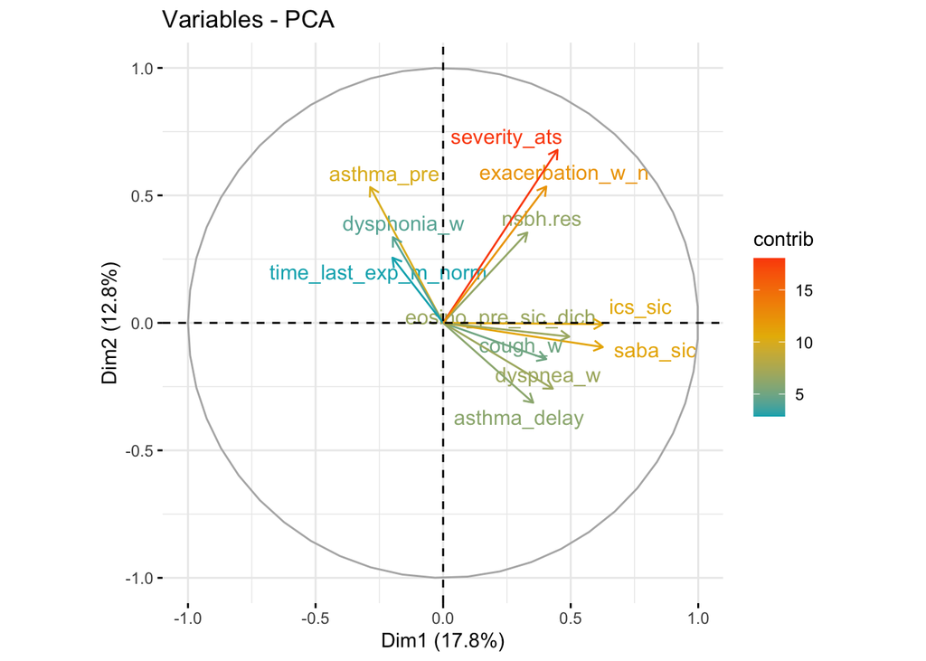

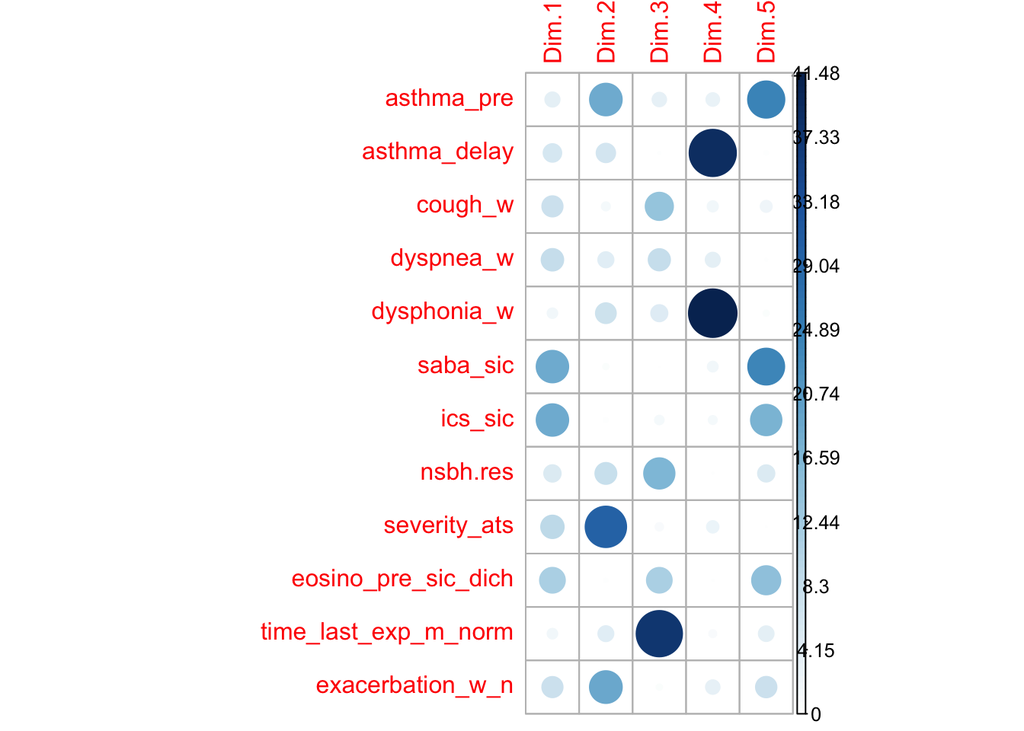

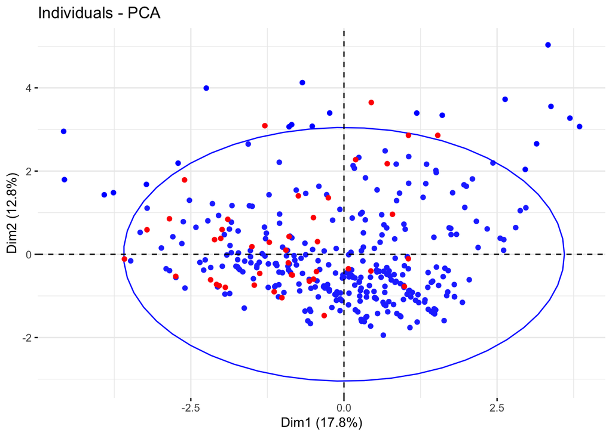

## analyse de sensibilité avec imputation des données manquantes

```
## Class: mids
## Number of multiple imputations:  5
## Imputation methods:
##           asthma_pre         asthma_delay              cough_w
##                "pmm"                "pmm"                "pmm"
##            dyspnea_w          dysphonia_w             saba_sic
##                "pmm"                "pmm"                "pmm"
##              ics_sic             nsbh.res         severity_ats
##                "pmm"                "pmm"                "pmm"
##  eosino_pre_sic_dich time_last_exp_m_norm     exacerbation_w_n
##                   ""                "pmm"                "pmm"
## PredictorMatrix:
##              asthma_pre asthma_delay cough_w dyspnea_w dysphonia_w saba_sic
## asthma_pre            0            1       1         1           1        1
## asthma_delay          1            0       1         1           1        1
## cough_w               1            1       0         1           1        1
## dyspnea_w             1            1       1         0           1        1
## dysphonia_w           1            1       1         1           0        1
## saba_sic              1            1       1         1           1        0
##              ics_sic nsbh.res severity_ats eosino_pre_sic_dich
## asthma_pre         1        1            1                   1
## asthma_delay       1        1            1                   1
## cough_w            1        1            1                   1
## dyspnea_w          1        1            1                   1
## dysphonia_w        1        1            1                   1
## saba_sic           1        1            1                   1
##              time_last_exp_m_norm exacerbation_w_n
## asthma_pre                      1                1
## asthma_delay                    1                1
## cough_w                         1                1
## dyspnea_w                       1                1
## dysphonia_w                     1                1
## saba_sic                        1                1
```

```
##
## Call:
## glm(formula = eosino_pre_sic_dich ~ asthma_pre + saba_sic + ics_sic +
##     nsbh.res + time_last_exp_m_norm + exacerbation_w_n, family = binomial,
##     data = msacplt)
##
## Deviance Residuals:
##     Min       1Q   Median       3Q      Max
## -1.5631  -0.9694  -0.6522   1.1020   2.3320
##
## Coefficients:
##                            Estimate Std. Error z value Pr(>|z|)
## (Intercept)                -1.82581    0.31268  -5.839 5.24e-09 ***
## asthma_preyes              -0.58655    0.35286  -1.662 0.096456 .
## saba_sicyes                 0.66778    0.24329   2.745 0.006055 **
## ics_sicyes                  0.26201    0.24145   1.085 0.277850
## nsbh.resmild                0.86247    0.29724   2.902 0.003713 **
## nsbh.resmoderate to severe  1.22019    0.31453   3.879 0.000105 ***
## time_last_exp_m_norm       -0.19011    0.08933  -2.128 0.033315 *
## exacerbation_w_n            0.11851    0.08577   1.382 0.167094
## ---
## Signif. codes:  0 '***' 0.001 '**' 0.01 '*' 0.05 '.' 0.1 ' ' 1
##
## (Dispersion parameter for binomial family taken to be 1)
##
##     Null deviance: 567.37  on 421  degrees of freedom
## Residual deviance: 518.42  on 414  degrees of freedom
## AIC: 534.42
##
## Number of Fisher Scoring iterations: 4
```

| **Characteristic** | **OR**<sup>1</sup> | **95% CI**<sup>1</sup> | **p-value** |
| --- | --- | --- | --- |
| asthma_pre |  |  |  |
| no | — | — |  |
| yes | 0.56 | 0.27, 1.09 | 0.10 |
| saba_sic |  |  |  |
| no | — | — |  |
| yes | 1.95 | 1.22, 3.16 | 0.006 |
| ics_sic |  |  |  |
| no | — | — |  |
| yes | 1.30 | 0.81, 2.09 | 0.3 |
| nsbh.res |  |  |  |
| negative | — | — |  |
| mild | 2.37 | 1.34, 4.31 | 0.004 |
| moderate to severe | 3.39 | 1.85, 6.37 | <0.001 |
| time_last_exp_m_norm | 0.83 | 0.69, 0.98 | 0.033 |
| exacerbation_w_n | 1.13 | 0.96, 1.35 | 0.2 |

<sup>*1*</sup> OR = Odds Ratio, CI = Confidence Interval

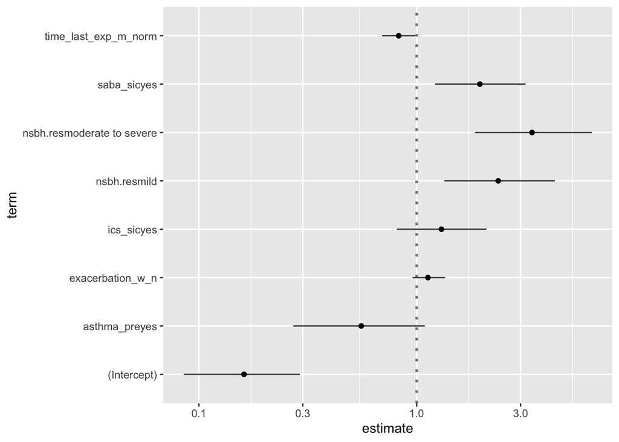

##analyse par ACP pour les variable du modèle finale avec et sans les données manquantes du modèle complet.

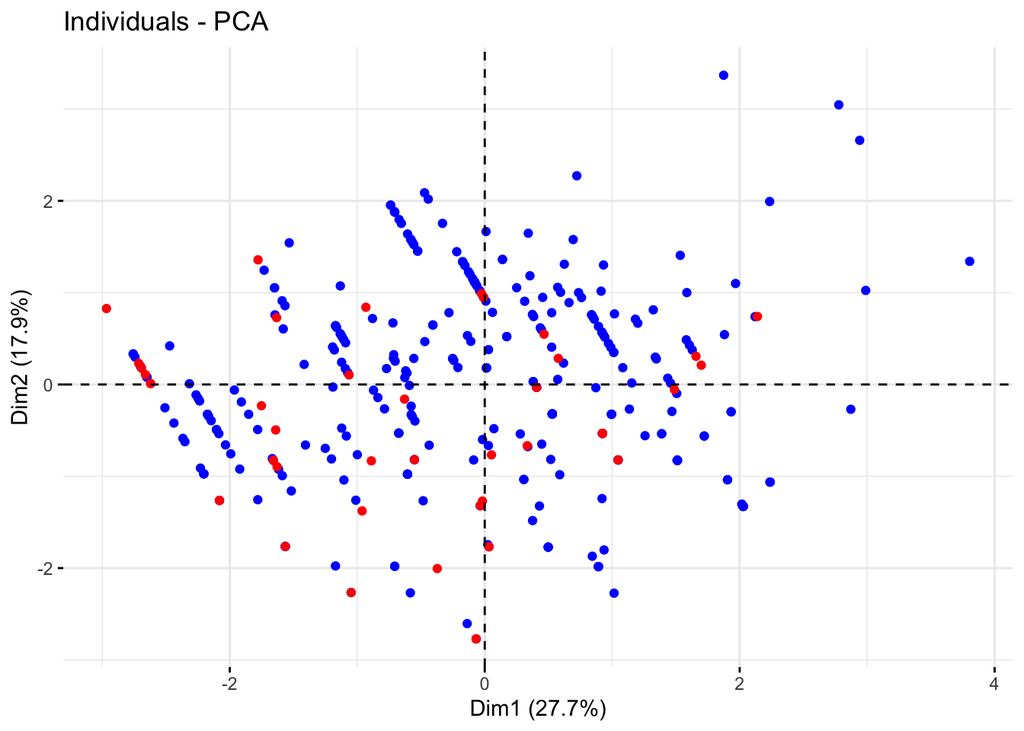

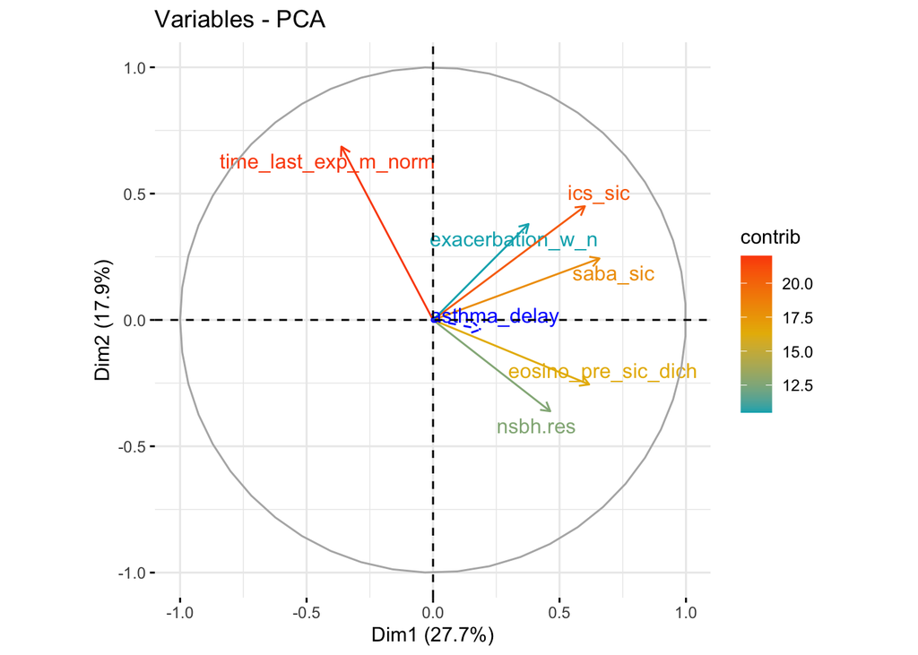

Rapport entre le délai d’exposition et la classification en T2/non T2 en fonction sputum pré/post-sic

```
##
## Call:
## glm(formula = eosino_post_sic.3 ~ time_last_exp_m_norm + eosino_pre_sic,
##     family = binomial, data = dat)
##
## Deviance Residuals:
##     Min       1Q   Median       3Q      Max
## -3.4839  -1.2508   0.5753   0.9169   1.1171
##
## Coefficients:
##                      Estimate Std. Error z value Pr(>|z|)
## (Intercept)           0.17384    0.16478   1.055    0.291
## time_last_exp_m_norm  0.01992    0.10631   0.187    0.851
## eosino_pre_sic        0.29346    0.06313   4.649 3.34e-06 ***
## ---
## Signif. codes:  0 '***' 0.001 '**' 0.01 '*' 0.05 '.' 0.1 ' ' 1
##
## (Dispersion parameter for binomial family taken to be 1)
##
##     Null deviance: 433.13  on 365  degrees of freedom
## Residual deviance: 377.35  on 363  degrees of freedom
##   (56 observations deleted due to missingness)
## AIC: 383.35
##
## Number of Fisher Scoring iterations: 7
```

| **Characteristic** | **OR**<sup>1</sup> | **95% CI**<sup>1</sup> | **p-value** |
| --- | --- | --- | --- |
| time_last_exp_m_norm | 1.02 | 0.83, 1.26 | 0.9 |
| eosino_pre_sic | 1.34 | 1.20, 1.54 | <0.001 |

<sup>*1*</sup> OR = Odds Ratio, CI = Confidence Interval

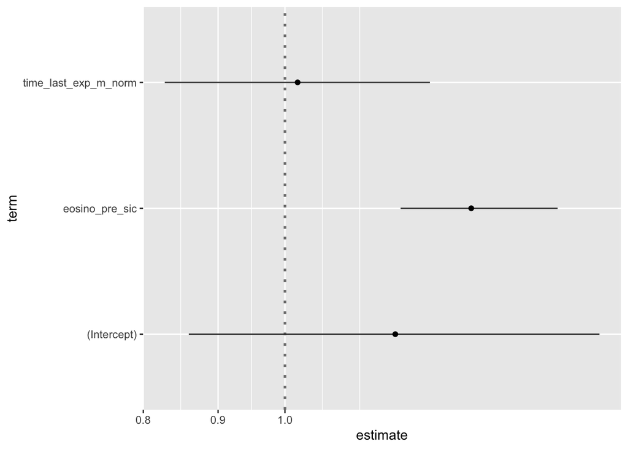

```
## Analysis of Deviance Table
##
## Model 1: eosino_post_sic.3 ~ time_last_exp_m_norm + eosino_pre_sic
## Model 2: eosino_post_sic.3 ~ 1
##   Resid. Df Resid. Dev Df Deviance  Pr(>Chi)
## 1       363     377.35
## 2       365     433.13 -2  -55.782 7.711e-13 ***
## ---
## Signif. codes:  0 '***' 0.001 '**' 0.01 '*' 0.05 '.' 0.1 ' ' 1
```

```
##
## Call:
## glm(formula = eosino_pre_sic.3 ~ time_last_exp_m_norm + eosino_post_sic,
##     family = binomial, data = dat)
##
## Deviance Residuals:
##     Min       1Q   Median       3Q      Max
## -2.5065  -0.8717  -0.6871   1.1093   1.8520
##
## Coefficients:
##                      Estimate Std. Error z value Pr(>|z|)
## (Intercept)          -1.14536    0.16059  -7.132 9.88e-13 ***
## time_last_exp_m_norm -0.26871    0.09752  -2.755  0.00586 **
## eosino_post_sic       0.06458    0.01032   6.256 3.94e-10 ***
## ---
## Signif. codes:  0 '***' 0.001 '**' 0.01 '*' 0.05 '.' 0.1 ' ' 1
##
## (Dispersion parameter for binomial family taken to be 1)
##
##     Null deviance: 496.47  on 366  degrees of freedom
## Residual deviance: 426.24  on 364  degrees of freedom
##   (55 observations deleted due to missingness)
## AIC: 432.24
##
## Number of Fisher Scoring iterations: 4
```

| **Characteristic** | **OR**<sup>1</sup> | **95% CI**<sup>1</sup> | **p-value** |
| --- | --- | --- | --- |
| time_last_exp_m_norm | 0.76 | 0.63, 0.92 | 0.006 |
| eosino_post_sic | 1.07 | 1.05, 1.09 | <0.001 |

<sup>*1*</sup> OR = Odds Ratio, CI = Confidence Interval

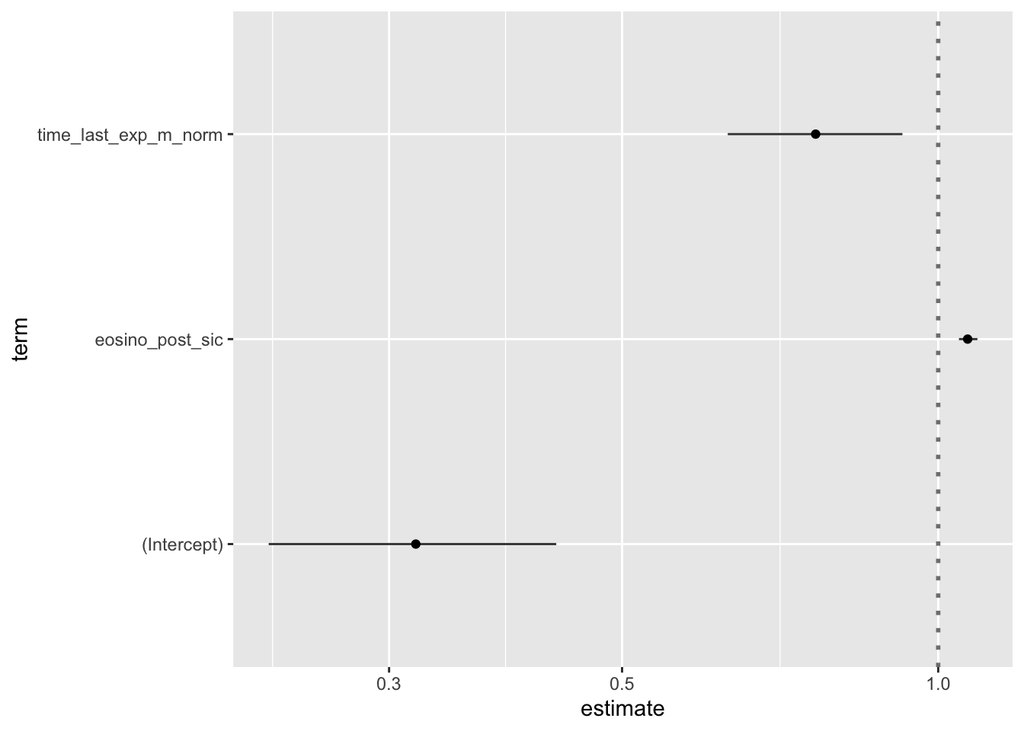

```
## Analysis of Deviance Table
##
## Model 1: eosino_pre_sic.3 ~ time_last_exp_m_norm + eosino_post_sic
## Model 2: eosino_pre_sic.3 ~ 1
##   Resid. Df Resid. Dev Df Deviance  Pr(>Chi)
## 1       364     426.24
## 2       366     496.47 -2  -70.229 5.623e-16 ***
## ---
## Signif. codes:  0 '***' 0.001 '**' 0.01 '*' 0.05 '.' 0.1 ' ' 1
```

#Nouvelles analyses, ## variable avec association en régression logistique univarié avec p<0,1 : asthma_pre+asthma_delay+ cough_w+ dyspnea_w+ dysphonia_w+ saba_sic+laba_sic+exa_2+baseline_fev1+tiffeneau +airway_obstruction+nsbh.res+severity_ats+ ics_sic+time_last_exp_m_norm+exacerbation_w_n

Facteurs connus comme étant lié à l’inflmamation T2: âge, IMC, sévérité selon les critère ATS, le niveau d’HRB, l’atopie et le tabac.

## modèle complet

```
##
## Call:
## glm(formula = eosino_pre_sic_dich ~ age + bmi + severity_ats +
##     nsbh.res + atopy + smoker + asthma_pre + time_last_exp_m_norm +
##     dysphonia_w + asthma_delay + cough_w + dyspnea_w + saba_w +
##     ics_w, family = binomial, data = (dr %>% drop_na()))
##
## Deviance Residuals:
##     Min       1Q   Median       3Q      Max
## -1.7304  -1.0020  -0.6149   1.1144   2.0589
##
## Coefficients:
##                              Estimate Std. Error z value Pr(>|z|)
## (Intercept)                -2.3023672  1.0950212  -2.103  0.03550 *
## age                         0.0119873  0.0137756   0.870  0.38420
## bmi                        -0.0193657  0.0274872  -0.705  0.48110
## severity_atsyes             0.0344660  0.3397204   0.101  0.91919
## nsbh.resmild                0.9151578  0.3579078   2.557  0.01056 *
## nsbh.resmoderate to severe  1.2039548  0.3958028   3.042  0.00235 **
## atopyyes                    0.0177066  0.2599614   0.068  0.94570
## smokerex                   -0.3393143  0.3621042  -0.937  0.34873
## smokernever                -0.1493713  0.3195741  -0.467  0.64021
## asthma_preyes              -0.8004695  0.4941659  -1.620  0.10527
## time_last_exp_m_norm       -0.2552608  0.1075548  -2.373  0.01763 *
## dysphonia_wyes             -0.3546110  0.3866165  -0.917  0.35903
## asthma_delay                0.0003575  0.0013039   0.274  0.78397
## cough_wyes                  0.1558028  0.3803957   0.410  0.68211
## dyspnea_wyes                0.1994285  0.4844188   0.412  0.68057
## saba_wyes                   0.8174396  0.3600161   2.271  0.02317 *
## ics_wyes                    0.3938633  0.3319601   1.186  0.23543
## ---
## Signif. codes:  0 '***' 0.001 '**' 0.01 '*' 0.05 '.' 0.1 ' ' 1
##
## (Dispersion parameter for binomial family taken to be 1)
##
##     Null deviance: 426.35  on 319  degrees of freedom
## Residual deviance: 381.69  on 303  degrees of freedom
## AIC: 415.69
##
## Number of Fisher Scoring iterations: 4
```

| **Characteristic** | **OR**<sup>1</sup> | **95% CI**<sup>1</sup> | **p-value** |
| --- | --- | --- | --- |
| age | 1.01 | 0.99, 1.04 | 0.4 |
| bmi | 0.98 | 0.93, 1.03 | 0.5 |
| severity_ats |  |  |  |
| no | — | — |  |
| yes | 1.04 | 0.53, 2.02 | >0.9 |
| nsbh.res |  |  |  |
| negative | — | — |  |
| mild | 2.50 | 1.26, 5.18 | 0.011 |
| moderate to severe | 3.33 | 1.56, 7.41 | 0.002 |
| atopy |  |  |  |
| no | — | — |  |
| yes | 1.02 | 0.61, 1.70 | >0.9 |
| smoker |  |  |  |
| current | — | — |  |
| ex | 0.71 | 0.35, 1.45 | 0.3 |
| never | 0.86 | 0.46, 1.62 | 0.6 |
| asthma_pre |  |  |  |
| no | — | — |  |
| yes | 0.45 | 0.16, 1.14 | 0.11 |
| time_last_exp_m_norm | 0.77 | 0.63, 0.96 | 0.018 |
| dysphonia_w |  |  |  |
| no | — | — |  |
| yes | 0.70 | 0.32, 1.47 | 0.4 |
| asthma_delay | 1.00 | 1.00, 1.00 | 0.8 |
| cough_w |  |  |  |
| no | — | — |  |
| yes | 1.17 | 0.56, 2.51 | 0.7 |
| dyspnea_w |  |  |  |
| no | — | — |  |
| yes | 1.22 | 0.48, 3.30 | 0.7 |
| saba_w |  |  |  |
| no | — | — |  |
| yes | 2.26 | 1.14, 4.70 | 0.023 |
| ics_w |  |  |  |
| no | — | — |  |
| yes | 1.48 | 0.78, 2.87 | 0.2 |

<sup>*1*</sup> OR = Odds Ratio, CI = Confidence Interval

```
##                          GVIF Df GVIF^(1/(2*Df))
## age                  1.450295  1        1.204282
## bmi                  1.126993  1        1.061599
## severity_ats         1.275346  1        1.129312
## nsbh.res             1.104332  2        1.025121
## atopy                1.112199  1        1.054608
## smoker               1.157177  2        1.037170
## asthma_pre           1.126211  1        1.061231
## time_last_exp_m_norm 1.117564  1        1.057149
## dysphonia_w          1.147244  1        1.071095
## asthma_delay         1.422997  1        1.192894
## cough_w              1.083335  1        1.040834
## dyspnea_w            1.114792  1        1.055837
## saba_w               1.190172  1        1.090950
## ics_w                1.288114  1        1.134951
```

```
## Start:  AIC=415.69
## eosino_pre_sic_dich ~ age + bmi + severity_ats + nsbh.res + atopy +
##     smoker + asthma_pre + time_last_exp_m_norm + dysphonia_w +
##     asthma_delay + cough_w + dyspnea_w + saba_w + ics_w
##
##                        Df Deviance    AIC
## - smoker                2   382.59 412.59
## - atopy                 1   381.70 413.70
## - severity_ats          1   381.70 413.70
## - asthma_delay          1   381.77 413.77
## - cough_w               1   381.86 413.86
## - dyspnea_w             1   381.86 413.86
## - bmi                   1   382.20 414.20
## - age                   1   382.45 414.45
## - dysphonia_w           1   382.55 414.55
## - ics_w                 1   383.11 415.11
## <none>                      381.69 415.69
## - asthma_pre            1   384.52 416.52
## - saba_w                1   387.15 419.15
## - time_last_exp_m_norm  1   387.39 419.39
## - nsbh.res              2   392.07 422.07
##
## Step:  AIC=412.59
## eosino_pre_sic_dich ~ age + bmi + severity_ats + nsbh.res + atopy +
##     asthma_pre + time_last_exp_m_norm + dysphonia_w + asthma_delay +
##     cough_w + dyspnea_w + saba_w + ics_w
##
##                        Df Deviance    AIC
## - severity_ats          1   382.61 410.61
## - atopy                 1   382.61 410.61
## - asthma_delay          1   382.65 410.65
## - dyspnea_w             1   382.74 410.74
## - cough_w               1   382.76 410.76
## - age                   1   383.28 411.28
## - bmi                   1   383.30 411.30
## - dysphonia_w           1   383.35 411.35
## - ics_w                 1   383.86 411.86
## <none>                      382.59 412.59
## - asthma_pre            1   385.22 413.22
## - saba_w                1   387.82 415.82
```

[output cut: 113 more lines]

```
## - time_last_exp_m_norm  1   391.62 405.62
## - saba_w                1   391.98 405.98
## - nsbh.res              2   395.46 407.46
##
## Step:  AIC=399.44
## eosino_pre_sic_dich ~ nsbh.res + asthma_pre + time_last_exp_m_norm +
##     saba_w + ics_w
##
##                        Df Deviance    AIC
## <none>                      385.44 399.44
## - ics_w                 1   387.70 399.70
## - asthma_pre            1   389.23 401.23
## - time_last_exp_m_norm  1   392.21 404.21
## - saba_w                1   392.52 404.52
## - nsbh.res              2   396.74 406.74
```

```
##
## Call:  glm(formula = eosino_pre_sic_dich ~ nsbh.res + asthma_pre + time_last_exp_m_norm +
##     saba_w + ics_w, family = binomial, data = (dr %>% drop_na()))
##
## Coefficients:
##                (Intercept)                nsbh.resmild
##                    -2.2545                      0.9185
## nsbh.resmoderate to severe               asthma_preyes
##                     1.2229                     -0.8656
##       time_last_exp_m_norm                   saba_wyes
##                    -0.2632                      0.8781
##                   ics_wyes
##                     0.4510
##
## Degrees of Freedom: 319 Total (i.e. Null);  313 Residual
## Null Deviance:       426.3
## Residual Deviance: 385.4     AIC: 399.4
```

#modèle finale avec 320 observation

```
##
## Call:
## glm(formula = eosino_pre_sic_dich ~ nsbh.res + asthma_pre + time_last_exp_m_norm +
##     saba_w + ics_w, family = binomial, data = (dr %>% drop_na()))
##
## Deviance Residuals:
##     Min       1Q   Median       3Q      Max
## -1.4846  -1.0037  -0.6052   1.1522   2.0772
##
## Coefficients:
##                            Estimate Std. Error z value Pr(>|z|)
## (Intercept)                 -2.2545     0.4334  -5.201 1.98e-07 ***
## nsbh.resmild                 0.9185     0.3509   2.617  0.00886 **
## nsbh.resmoderate to severe   1.2229     0.3847   3.178  0.00148 **
## asthma_preyes               -0.8656     0.4660  -1.858  0.06321 .
## time_last_exp_m_norm        -0.2632     0.1017  -2.587  0.00968 **
## saba_wyes                    0.8781     0.3414   2.572  0.01011 *
## ics_wyes                     0.4510     0.3026   1.490  0.13613
## ---
## Signif. codes:  0 '***' 0.001 '**' 0.01 '*' 0.05 '.' 0.1 ' ' 1
##
## (Dispersion parameter for binomial family taken to be 1)
##
##     Null deviance: 426.35  on 319  degrees of freedom
## Residual deviance: 385.44  on 313  degrees of freedom
## AIC: 399.44
##
## Number of Fisher Scoring iterations: 4
```

| **Characteristic** | **OR**<sup>1</sup> | **95% CI**<sup>1</sup> | **p-value** |
| --- | --- | --- | --- |
| nsbh.res |  |  |  |
| negative | — | — |  |
| mild | 2.51 | 1.28, 5.13 | 0.009 |
| moderate to severe | 3.40 | 1.62, 7.39 | 0.001 |
| asthma_pre |  |  |  |
| no | — | — |  |
| yes | 0.42 | 0.16, 1.01 | 0.063 |
| time_last_exp_m_norm | 0.77 | 0.63, 0.94 | 0.010 |
| saba_w |  |  |  |
| no | — | — |  |
| yes | 2.41 | 1.25, 4.82 | 0.010 |
| ics_w |  |  |  |
| no | — | — |  |
| yes | 1.57 | 0.87, 2.87 | 0.14 |

<sup>*1*</sup> OR = Odds Ratio, CI = Confidence Interval

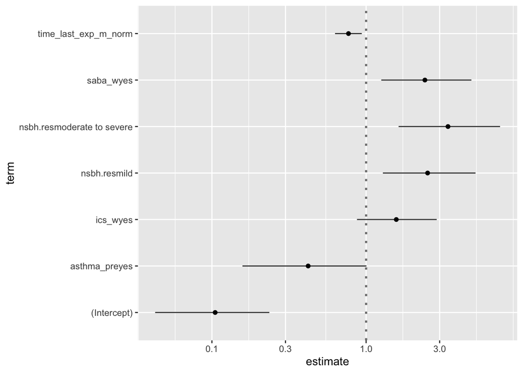

```
## Analysis of Deviance Table
##
## Model 1: eosino_pre_sic_dich ~ 1
## Model 2: eosino_pre_sic_dich ~ nsbh.res + asthma_pre + time_last_exp_m_norm +
##     saba_w + ics_w
##   Resid. Df Resid. Dev Df Deviance  Pr(>Chi)
## 1       319     426.35
## 2       313     385.44  6   40.909 3.017e-07 ***
## ---
## Signif. codes:  0 '***' 0.001 '**' 0.01 '*' 0.05 '.' 0.1 ' ' 1
```

```
##
## Call:
## glm(formula = eosino_pre_sic_dich ~ nsbh.res + asthma_pre + time_last_exp_m_norm +
##     saba_w + ics_w, family = binomial, data = (dr %>% drop_na(nsbh.res,
##     asthma_pre, time_last_exp_m_norm, saba_w, ics_w)))
##
## Deviance Residuals:
##     Min       1Q   Median       3Q      Max
## -1.4519  -1.0142  -0.6431   1.1424   2.0536
##
## Coefficients:
##                            Estimate Std. Error z value Pr(>|z|)
## (Intercept)                -2.30960    0.42108  -5.485 4.14e-08 ***
## nsbh.resmild                0.99046    0.34437   2.876  0.00403 **
## nsbh.resmoderate to severe  1.28661    0.37343   3.445  0.00057 ***
## asthma_preyes              -0.63789    0.40327  -1.582  0.11369
## time_last_exp_m_norm       -0.24692    0.09756  -2.531  0.01137 *
## saba_wyes                   0.88280    0.32799   2.691  0.00711 **
## ics_wyes                    0.38969    0.28396   1.372  0.16997
## ---
## Signif. codes:  0 '***' 0.001 '**' 0.01 '*' 0.05 '.' 0.1 ' ' 1
##
## (Dispersion parameter for binomial family taken to be 1)
##
##     Null deviance: 465.81  on 349  degrees of freedom
## Residual deviance: 423.16  on 343  degrees of freedom
## AIC: 437.16
##
## Number of Fisher Scoring iterations: 4
```

| **Characteristic** | **OR**<sup>1</sup> | **95% CI**<sup>1</sup> | **p-value** |
| --- | --- | --- | --- |
| nsbh.res |  |  |  |
| negative | — | — |  |
| mild | 2.69 | 1.40, 5.45 | 0.004 |
| moderate to severe | 3.62 | 1.77, 7.72 | <0.001 |
| asthma_pre |  |  |  |
| no | — | — |  |
| yes | 0.53 | 0.23, 1.13 | 0.11 |
| time_last_exp_m_norm | 0.78 | 0.64, 0.95 | 0.011 |
| saba_w |  |  |  |
| no | — | — |  |
| yes | 2.42 | 1.29, 4.71 | 0.007 |
| ics_w |  |  |  |
| no | — | — |  |
| yes | 1.48 | 0.85, 2.60 | 0.2 |

<sup>*1*</sup> OR = Odds Ratio, CI = Confidence Interval

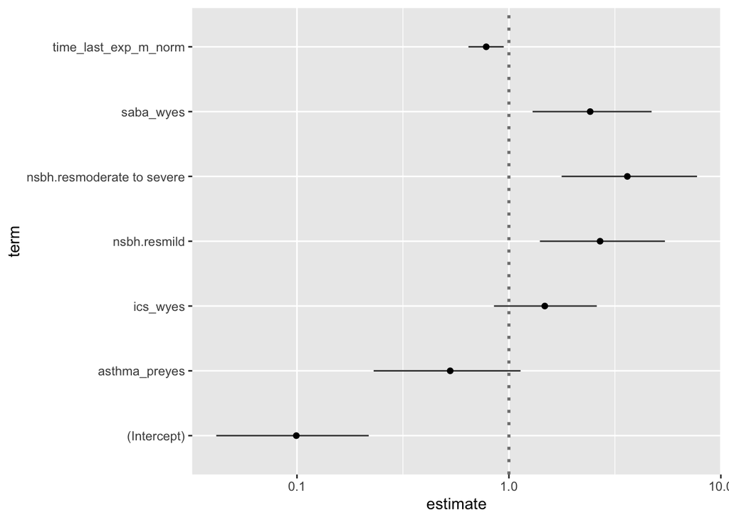

#imputation des données manquantes

```
## Class: mids
## Number of multiple imputations:  5
## Imputation methods:
##                  age                  bmi         severity_ats
##                   ""                   ""                "pmm"
##             nsbh.res                atopy               smoker
##                "pmm"                "pmm"                   ""
##           asthma_pre time_last_exp_m_norm          dysphonia_w
##                "pmm"                "pmm"                "pmm"
##         asthma_delay              cough_w            dyspnea_w
##                "pmm"                "pmm"                "pmm"
##               saba_w                ics_w  eosino_pre_sic_dich
##                "pmm"                "pmm"                   ""
## PredictorMatrix:
##              age bmi severity_ats nsbh.res atopy smoker asthma_pre
## age            0   1            1        1     1      1          1
## bmi            1   0            1        1     1      1          1
## severity_ats   1   1            0        1     1      1          1
## nsbh.res       1   1            1        0     1      1          1
## atopy          1   1            1        1     0      1          1
## smoker         1   1            1        1     1      0          1
##              time_last_exp_m_norm dysphonia_w asthma_delay cough_w dyspnea_w
## age                             1           1            1       1         1
## bmi                             1           1            1       1         1
## severity_ats                    1           1            1       1         1
## nsbh.res                        1           1            1       1         1
## atopy                           1           1            1       1         1
## smoker                          1           1            1       1         1
##              saba_w ics_w eosino_pre_sic_dich
## age               1     1                   1
## bmi               1     1                   1
## severity_ats      1     1                   1
## nsbh.res          1     1                   1
## atopy             1     1                   1
## smoker            1     1                   1
```

```
##
## Call:
## glm(formula = eosino_pre_sic_dich ~ nsbh.res + asthma_pre + time_last_exp_m_norm +
##     saba_w + ics_w, family = binomial, data = (drm))
##
## Deviance Residuals:
##     Min       1Q   Median       3Q      Max
## -1.4614  -1.0312  -0.6405   1.1634   2.0387
##
## Coefficients:
##                            Estimate Std. Error z value Pr(>|z|)
## (Intercept)                -2.19437    0.36757  -5.970 2.37e-09 ***
## nsbh.resmild                0.79126    0.28923   2.736  0.00622 **
## nsbh.resmoderate to severe  1.00084    0.31059   3.222  0.00127 **
## asthma_preyes              -0.48836    0.34953  -1.397  0.16236
## time_last_exp_m_norm       -0.25492    0.08854  -2.879  0.00399 **
## saba_wyes                   0.97172    0.29858   3.254  0.00114 **
## ics_wyes                    0.48025    0.26080   1.841  0.06556 .
## ---
## Signif. codes:  0 '***' 0.001 '**' 0.01 '*' 0.05 '.' 0.1 ' ' 1
##
## (Dispersion parameter for binomial family taken to be 1)
##
##     Null deviance: 567.37  on 421  degrees of freedom
## Residual deviance: 518.09  on 415  degrees of freedom
## AIC: 532.09
##
## Number of Fisher Scoring iterations: 4
```

| **Characteristic** | **OR**<sup>1</sup> | **95% CI**<sup>1</sup> | **p-value** |
| --- | --- | --- | --- |
| nsbh.res |  |  |  |
| negative | — | — |  |
| mild | 2.21 | 1.26, 3.95 | 0.006 |
| moderate to severe | 2.72 | 1.49, 5.06 | 0.001 |
| asthma_pre |  |  |  |
| no | — | — |  |
| yes | 0.61 | 0.30, 1.20 | 0.2 |
| time_last_exp_m_norm | 0.77 | 0.65, 0.92 | 0.004 |
| saba_w |  |  |  |
| no | — | — |  |
| yes | 2.64 | 1.49, 4.84 | 0.001 |
| ics_w |  |  |  |
| no | — | — |  |
| yes | 1.62 | 0.97, 2.72 | 0.066 |

<sup>*1*</sup> OR = Odds Ratio, CI = Confidence Interval

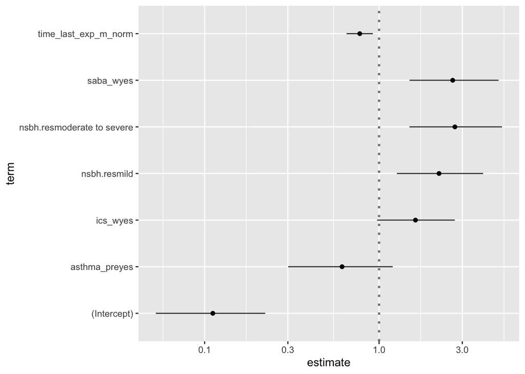

| **Characteristic** | Modèle réduit méthode cas complet **OR**<sup>1</sup> | Modèle réduit méthode cas complet **95% CI**<sup>1</sup> | Modèle réduit méthode cas complet **p-value** | Modèle réduit avec imputation multiple **OR**<sup>1</sup> | Modèle réduit avec imputation multiple **95% CI**<sup>1</sup> | Modèle réduit avec imputation multiple **p-value** |
| --- | --- | --- | --- | --- | --- | --- |
| nsbh.res |  |  |  |  |  |  |
| negative | — | — |  | — | — |  |
| mild | 2.51 | 1.28, 5.13 | 0.009 | 2.21 | 1.26, 3.95 | 0.006 |
| moderate to severe | 3.40 | 1.62, 7.39 | 0.001 | 2.72 | 1.49, 5.06 | 0.001 |
| asthma_pre |  |  |  |  |  |  |
| no | — | — |  | — | — |  |
| yes | 0.42 | 0.16, 1.01 | 0.063 | 0.61 | 0.30, 1.20 | 0.2 |
| time_last_exp_m_norm | 0.77 | 0.63, 0.94 | 0.010 | 0.77 | 0.65, 0.92 | 0.004 |
| saba_w |  |  |  |  |  |  |
| no | — | — |  | — | — |  |
| yes | 2.41 | 1.25, 4.82 | 0.010 | 2.64 | 1.49, 4.84 | 0.001 |
| ics_w |  |  |  |  |  |  |
| no | — | — |  | — | — |  |
| yes | 1.57 | 0.87, 2.87 | 0.14 | 1.62 | 0.97, 2.72 | 0.066 |

<sup>*1*</sup> OR = Odds Ratio, CI = Confidence Interval

# tableau univarié

```
##                   explanatory             OR (univarié)
## 1                         age 1.01 (1.00-1.03, p=0.102)
## 2                         bmi 0.98 (0.94-1.01, p=0.225)
## 3             severity_atsyes 1.59 (0.95-2.66, p=0.080)
## 4                nsbh.resmild 2.46 (1.40-4.45, p=0.002)
## 5  nsbh.resmoderate to severe 3.47 (1.90-6.51, p<0.001)
## 6                    atopyyes 0.86 (0.58-1.28, p=0.467)
## 7                    smokerex 1.14 (0.66-1.99, p=0.643)
## 8                 smokernever 1.09 (0.67-1.81, p=0.727)
## 9               asthma_preyes 0.55 (0.28-1.04, p=0.075)
## 10       time_last_exp_m_norm 0.77 (0.65-0.91, p=0.002)
## 11             dysphonia_wyes 0.49 (0.26-0.90, p=0.026)
## 12               asthma_delay 1.00 (1.00-1.00, p=0.012)
## 13                 cough_wyes 1.74 (1.01-3.07, p=0.050)
## 14               dyspnea_wyes 1.88 (0.94-4.02, p=0.087)
## 15                  saba_wyes 3.42 (1.96-6.27, p<0.001)
## 16                   ics_wyes 2.25 (1.39-3.74, p=0.001)
```

| explanatory | OR (univarié) |
| --- | --- |
| age | 1.01 (1.00-1.03, p=0.102) |
| bmi | 0.98 (0.94-1.01, p=0.225) |
| severity_atsyes | 1.59 (0.95-2.66, p=0.080) |
| nsbh.resmild | 2.46 (1.40-4.45, p=0.002) |
| nsbh.resmoderate to severe | 3.47 (1.90-6.51, p<0.001) |
| atopyyes | 0.86 (0.58-1.28, p=0.467) |
| smokerex | 1.14 (0.66-1.99, p=0.643) |
| smokernever | 1.09 (0.67-1.81, p=0.727) |
| asthma_preyes | 0.55 (0.28-1.04, p=0.075) |
| time_last_exp_m_norm | 0.77 (0.65-0.91, p=0.002) |
| dysphonia_wyes | 0.49 (0.26-0.90, p=0.026) |
| asthma_delay | 1.00 (1.00-1.00, p=0.012) |
| cough_wyes | 1.74 (1.01-3.07, p=0.050) |
| dyspnea_wyes | 1.88 (0.94-4.02, p=0.087) |
| saba_wyes | 3.42 (1.96-6.27, p<0.001) |
| ics_wyes | 2.25 (1.39-3.74, p=0.001) |